# project1

## Load & Explore Data

```python
# Import libraries
import pandas as pd
import numpy as np
import matplotlib.pyplot as plt
import seaborn as sns

from sklearn.model_selection import train_test_split, cross_validate, cross_val_score, KFold
from sklearn.linear_model import LinearRegression
from sklearn.preprocessing import StandardScaler
from sklearn.pipeline import Pipeline
from sklearn.metrics import mean_squared_error, r2_score
```

```python
# Mount Google Drive
from google.colab import drive
drive.mount('/content/drive')
```

```python
# Load Medical Insurance Payout dataset
data = pd.read_csv('/content/drive/MyDrive/Math237Fall25/Datasets/expenses.csv')
data.head()
```

|  | age | sex | bmi | children | smoker | region | charges |
| --- | --- | --- | --- | --- | --- | --- | --- |
| 0 | 19 | female | 27.900 | 0 | yes | southwest | 16884.92400 |
| 1 | 18 | male | 33.770 | 1 | no | southeast | 1725.55230 |
| 2 | 28 | male | 33.000 | 3 | no | southeast | 4449.46200 |
| 3 | 33 | male | 22.705 | 0 | no | northwest | 21984.47061 |
| 4 | 32 | male | 28.880 | 0 | no | northwest | 3866.85520 |

```python
# Quick look at data

data.info()
data.shape
```

```
<class 'pandas.core.frame.DataFrame'>
RangeIndex: 1338 entries, 0 to 1337
Data columns (total 7 columns):
 #   Column    Non-Null Count  Dtype
---  ------    --------------  -----
 0   age       1338 non-null   int64
 1   sex       1338 non-null   object
 2   bmi       1338 non-null   float64
 3   children  1338 non-null   int64
 4   smoker    1338 non-null   object
 5   region    1338 non-null   object
 6   charges   1338 non-null   float64
dtypes: float64(2), int64(2), object(3)
memory usage: 73.3+ KB
```

```
(1338, 7)
```

```python
# Check missing values

data.isnull().sum()
```

|  | 0 |
| --- | --- |
| age | 0 |
| sex | 0 |
| bmi | 0 |
| children | 0 |
| smoker | 0 |
| region | 0 |
| charges | 0 |

**dtype:** int64

## Data Cleaning

```python
# Value counts for object variables

display(data['sex'].value_counts())
display(data['smoker'].value_counts())
display(data['region'].value_counts())
```

| sex | count |
| --- | --- |
| male | 676 |
| female | 662 |

**dtype:** int64

| smoker | count |
| --- | --- |
| no | 1064 |
| yes | 274 |

**dtype:** int64

| region | count |
| --- | --- |
| southeast | 364 |
| southwest | 325 |
| northwest | 325 |
| northeast | 324 |

**dtype:** int64

```python
# Transform binary variables (sex, smoker)

data['sex'] = data['sex'].map({'female': 0, 'male': 1})
data['smoker'] = data['smoker'].map({'no': 0, 'yes': 1})
print(data.head())
```

```
   age  sex     bmi  children  smoker     region      charges
0   19    0  27.900         0       1  southwest  16884.92400
1   18    1  33.770         1       0  southeast   1725.55230
2   28    1  33.000         3       0  southeast   4449.46200
3   33    1  22.705         0       0  northwest  21984.47061
4   32    1  28.880         0       0  northwest   3866.85520
```

```python
# One hot encoding for region column

data_clean = pd.get_dummies(data, columns=['region'], dtype=int)
print(data_clean.columns.tolist())

# Rename columns

data_clean = data_clean.rename(columns={'region_northeast': 'northeast', 'region_northwest': 'northwest', 'region_southeast': 'southeast', 'region_southwest': 'southwest'})
print(data_clean.head())
```

```
['age', 'sex', 'bmi', 'children', 'smoker', 'charges', 'region_northeast', 'region_northwest', 'region_southeast', 'region_southwest']
   age  sex     bmi  children  smoker      charges  northeast  northwest  \
0   19    0  27.900         0       1  16884.92400          0          0
1   18    1  33.770         1       0   1725.55230          0          0
2   28    1  33.000         3       0   4449.46200          0          0
3   33    1  22.705         0       0  21984.47061          0          1
4   32    1  28.880         0       0   3866.85520          0          1

   southeast  southwest
0          0          1
1          1          0
2          1          0
3          0          0
4          0          0
```

## Exploratory Data Analysis

```python
# Display basic statistics

data_clean.describe()
```

|  | age | sex | bmi | children | smoker | charges | northeast | northwest | southeast | southwest |
| --- | --- | --- | --- | --- | --- | --- | --- | --- | --- | --- |
| count | 1338.000000 | 1338.000000 | 1338.000000 | 1338.000000 | 1338.000000 | 1338.000000 | 1338.000000 | 1338.000000 | 1338.000000 | 1338.000000 |
| mean | 39.207025 | 0.505232 | 30.663397 | 1.094918 | 0.204783 | 13270.422265 | 0.242152 | 0.242900 | 0.272048 | 0.242900 |
| std | 14.049960 | 0.500160 | 6.098187 | 1.205493 | 0.403694 | 12110.011237 | 0.428546 | 0.428995 | 0.445181 | 0.428995 |
| min | 18.000000 | 0.000000 | 15.960000 | 0.000000 | 0.000000 | 1121.873900 | 0.000000 | 0.000000 | 0.000000 | 0.000000 |
| 25% | 27.000000 | 0.000000 | 26.296250 | 0.000000 | 0.000000 | 4740.287150 | 0.000000 | 0.000000 | 0.000000 | 0.000000 |
| 50% | 39.000000 | 1.000000 | 30.400000 | 1.000000 | 0.000000 | 9382.033000 | 0.000000 | 0.000000 | 0.000000 | 0.000000 |
| 75% | 51.000000 | 1.000000 | 34.693750 | 2.000000 | 0.000000 | 16639.912515 | 0.000000 | 0.000000 | 1.000000 | 0.000000 |
| max | 64.000000 | 1.000000 | 53.130000 | 5.000000 | 1.000000 | 63770.428010 | 1.000000 | 1.000000 | 1.000000 | 1.000000 |

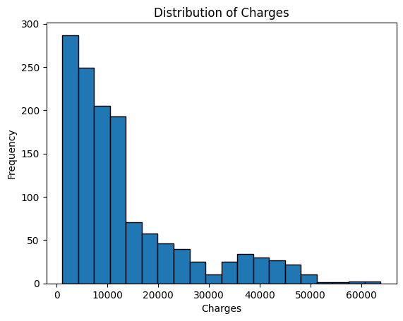

```python
# Distribution of target variable

plt.hist(data_clean['charges'], bins=20, edgecolor='black')
plt.xlabel('Charges')
plt.ylabel('Frequency')
plt.title('Distribution of Charges')
plt.show()
```

```python
# Calculate correlation matric

corr_matrix = data_clean.corr()
print(corr_matrix['charges'].sort_values(key=abs, ascending=False))
```

```
charges      1.000000
smoker       0.787251
age          0.299008
bmi          0.198341
southeast    0.073982
children     0.067998
sex          0.057292
southwest   -0.043210
northwest   -0.039905
northeast    0.006349
Name: charges, dtype: float64
```

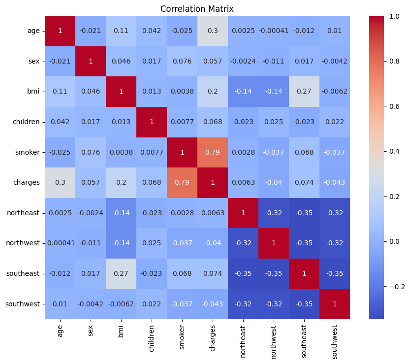

```python
# Visualize correlation matrix

plt.figure(figsize=(10, 8))
sns.heatmap(corr_matrix, annot=True, cmap='coolwarm')
plt.title('Correlation Matrix')
plt.show()
```

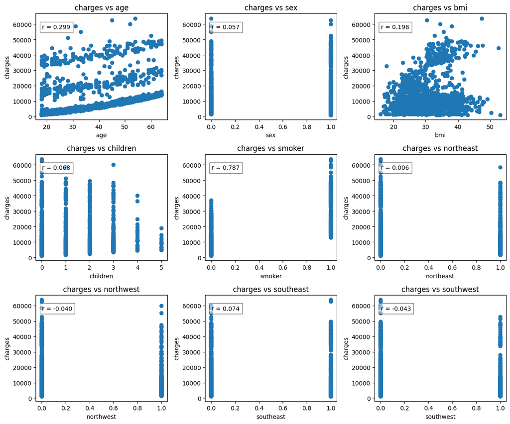

```python
# Scatter plots of features vs charges

features = ['age', 'sex', 'bmi', 'children', 'smoker', 'northeast', 'northwest', 'southeast', 'southwest']
fig,axes = plt.subplots(nrows=3, ncols=3, figsize=(12,10))
axes = axes.flatten()
for idx, feature in enumerate(features):
    axes[idx].scatter(data_clean[feature], data_clean['charges'])
    axes[idx].set_xlabel(feature)
    axes[idx].set_ylabel('charges')
    axes[idx].set_title(f'charges vs {feature}')

    corr = data_clean[feature].corr(data_clean['charges'])
    axes[idx].text(0.05, 0.9, f'r = {corr:.3f}', transform=axes[idx].transAxes, verticalalignment='top', bbox=dict(facecolor='white', alpha=0.5))

plt.tight_layout()
plt.show()
```

## Prepare Data for Multiple Regression

```python
# Define features (X) & target (y)

features = ['age', 'sex', 'bmi', 'children', 'smoker', 'northeast', 'northwest', 'southeast', 'southwest']

X_all = data_clean[features]
y = data_clean['charges']

print("Feature matrix X shape:", X_all.shape)
print("Target vector y shape:", y.shape)
```

```
Feature matrix X shape: (1338, 9)
Target vector y shape: (1338,)
```

### Nested Holdout Method

```python
# Create three-way split
# First split: 80% train+val, 20% test

X_temp, X_test, y_temp, y_test = train_test_split(X_all, y, test_size=0.2, random_state=42)

# Second split: 75% of temp = 60% train, 25% of temp = 20% val

X_train, X_val, y_train, y_val = train_test_split(X_temp, y_temp, test_size=0.25, random_state=42)

print("Data split sizes:")
print(f"Training:   {len(X_train)} samples ({len(X_train)/len(X_all)*100:.1f}%)")
print(f"Validation: {len(X_val)} samples ({len(X_val)/len(X_all)*100:.1f}%)")
print(f"Test:       {len(X_test)} samples ({len(X_test)/len(X_all)*100:.1f}%)")
print(f"Total:      {len(X_all)} samples")
```

```
Data split sizes:
Training:   802 samples (59.9%)
Validation: 268 samples (20.0%)
Test:       268 samples (20.0%)
Total:      1338 samples
```

```python
# Feature Set 1: Minimal (age, bmi, smoker)

features_minimal = ['age', 'bmi', 'smoker']

# Feature set 2: Basic (smoker, age, bmi, children, sex)

features_basic = ['age', 'sex', 'bmi', 'children', 'smoker']

# Feature Set 3: All original features

features_all = list(X_all.columns)

# Feature Set 4: Engineered features
# Create weight groups based on bmi (binning)

X_engineered = X_all.copy()
X_engineered['bmi_category'] = pd.cut(X_engineered['bmi'], bins=[0, 18.5, 25, 30, 100], labels=['Underweight', 'Normal', 'Overweight', 'Obese'])

# One hot encode bmi category

X_engineered = pd.get_dummies(X_engineered, columns=['bmi_category'], dtype=int)
X_engineered = X_engineered.rename(columns={'bmi_category_Underweight': 'underweight', 'bmi_category_Normal': 'normal', 'bmi_category_Overweight': 'overweight', 'bmi_category_Obese': 'obese'})
X_engineered = X_engineered.drop(columns=['bmi'])

# Age features

X_engineered['age_squared'] = (X_engineered['age'] ** 2)
X_engineered = X_engineered.drop(columns=['age'])
features_engineered = list(X_engineered.columns)

# List variables for all feature sets

print(f"Minimal Set features: {features_minimal}")
print(f"Basic Set features: {features_basic}")
print(f"All Original Set features: {features_all}")
print(f"Engineered Set features: {features_engineered}")
```

```
Minimal Set features: ['age', 'bmi', 'smoker']
Basic Set features: ['age', 'sex', 'bmi', 'children', 'smoker']
All Original Set features: ['age', 'sex', 'bmi', 'children', 'smoker', 'northeast', 'northwest', 'southeast', 'southwest']
Engineered Set features: ['sex', 'children', 'smoker', 'northeast', 'northwest', 'southeast', 'southwest', 'underweight', 'normal', 'overweight', 'obese', 'age_squared']
```

```python
# Store results for each feature set

results = []

# Dictionary of feature sets

feature_sets = {
    'Minimal': (X_all[features_minimal], features_minimal),
    'Basic': (X_all[features_basic], features_basic),
    'All Original': (X_all[features_all], features_all),
    'Engineered': (X_engineered[features_engineered], features_engineered),
}

# Indices for train/val/test split

indices = np.arange(len(y))
indices_temp, indices_test = train_test_split(indices, test_size=0.2, random_state=42)
indices_train, indices_val = train_test_split(indices_temp, test_size=0.25, random_state=42)
```

## Predictive Modeling

### Model Evaluation

```python
# Train & evaluate each feature set

for name, (X_features, feature_list) in feature_sets.items():
    X_train_fs = X_features.iloc[indices_train]
    X_val_fs = X_features.iloc[indices_val]
    X_test_fs = X_features.iloc[indices_test]

    y_train_fs = y.iloc[indices_train]
    y_val_fs = y.iloc[indices_val]
    y_test_fs = y.iloc[indices_test]

    # Create pipeline

    pipeline = Pipeline([
        ('scaler', StandardScaler()),
        ('model', LinearRegression())
    ])

    # Train on training set

    pipeline.fit(X_train_fs, y_train_fs)

    # Evaluate on training set

    y_train_pred = pipeline.predict(X_train_fs)
    train_rmse = np.sqrt(mean_squared_error(y_train_fs, y_train_pred))
    train_r2 = r2_score(y_train_fs, y_train_pred)

    # Evaluate on validation set

    y_val_pred = pipeline.predict(X_val_fs)
    val_rmse = np.sqrt(mean_squared_error(y_val_fs, y_val_pred))
    val_r2 = r2_score(y_val_fs, y_val_pred)

    # Record results

    results.append({
        'Feature Set': name,
        'Number of Features': len(feature_list),
        'Train RMSE': train_rmse,
        'Val RMSE': val_rmse,
        'Train R^2': train_r2,
        'Val R^2': val_r2,
        'Generalization Gap': val_rmse - train_rmse
    })
```

## Model Selection

```python
# Results dataframe

results_df = pd.DataFrame(results)
print("Model Selection Results (Validation Set):")
print(results_df.to_string(index=False))
```

```
Model Selection Results (Validation Set):
 Feature Set  Number of Features  Train RMSE    Val RMSE  Train R^2  Val R^2  Generalization Gap
     Minimal                   3 5906.524187 6796.473221   0.743240 0.725909          889.949033
       Basic                   5 5885.210368 6775.857579   0.745090 0.727569          890.647211
All Original                   9 5878.650181 6766.880761   0.745658 0.728291          888.230580
  Engineered                  12 5766.514004 6689.540692   0.755268 0.734466          923.026688
```

```python
# Select best model based on validation RMSE
best_idx = results_df['Val RMSE'].idxmin()
best_model = results_df.loc[best_idx, 'Feature Set']

print(f"Selected Model: {best_model}")
print(f"Validation RMSE: {results_df.loc[best_idx, 'Val RMSE']:.4f}")
print(f"Generalization Gap: {results_df.loc[best_idx, 'Generalization Gap']:.4f}")
```

```
Selected Model: Engineered
Validation RMSE: 6689.5407
Generalization Gap: 923.0267
```

## Final Performance on Test Set

```python
# Get selected feature set
selected_features = feature_sets[best_model][1]

if best_model == 'Engineered':
    X_selected = X_engineered[selected_features]
else:
    X_selected = X_all[selected_features]

# Combine train and validation indices
indices_train_val = np.concatenate([indices_train, indices_val])

# Use combined indices to create final train set
X_train_final = X_selected.iloc[indices_train_val]
y_train_final = y.iloc[indices_train_val]

# Get test set
X_test_final = X_selected.iloc[indices_test]
y_test_final = y.iloc[indices_test]

# Train final model on combined train & val set
final_pipeline = Pipeline([
    ('scaler', StandardScaler()),
    ('model', LinearRegression())
])

final_pipeline.fit(X_train_final, y_train_final)
```

```
Pipeline(steps=[('scaler', StandardScaler()), ('model', LinearRegression())])
```

```python
# Evaluate on train set
y_train_pred = final_pipeline.predict(X_train_final)
train_rmse = np.sqrt(mean_squared_error(y_train_final, y_train_pred))
train_r2 = r2_score(y_train_final, y_train_pred)

# Evaluate on test set
y_test_pred = final_pipeline.predict(X_test_final)
test_rmse = np.sqrt(mean_squared_error(y_test_final, y_test_pred))
test_r2 = r2_score(y_test_final, y_test_pred)

print(f"\nFinal Performance (Test Set):")
print(f"Model: {best_model}")
print(f"Train RMSE: {train_rmse:.4f}")
print(f"Train R²: {train_r2:.4f}")
print(f"Test RMSE: {test_rmse:.4f}")
print(f"Test R²: {test_r2:.4f}")
print(f"Generalization Gap: {test_rmse - train_rmse:.4f}")
```

```
Final Performance (Test Set):
Model: Engineered
Train RMSE: 6003.2146
Train R²: 0.7503
Test RMSE: 5825.8064
Test R²: 0.7814
Generalization Gap: -177.4081
```

```python
# Compare training vs test performance

comparison = pd.DataFrame({
    'Metric': ['R-squared', 'RMSE', 'Generalization Gap'],
    'Training': [train_r2, train_rmse, f"{val_rmse - train_rmse:.4f}"],
    'Test': [test_r2, test_rmse, f"{test_rmse - train_rmse:.4f}"]
})

print(comparison)
```

```
               Metric     Training         Test
0           R-squared     0.750311     0.781383
1                RMSE  6003.214583  5825.806436
2  Generalization Gap     686.3261    -177.4081
```

Performance Summary

- Model performs similarily on the training and test set; suggests the model generalizes well
- Model explains ~78.138% of the variance within the dataset; indicates a good fit
- Most important features: "smoker", "age_squared", "obese"

## Visualize Predictions

```python
# Extract and display coefficients

intercept = final_pipeline.named_steps['model'].intercept_
coefficients = final_pipeline.named_steps['model'].coef_

coef_df = pd.DataFrame({'Feature': selected_features, 'Coefficient': coefficients}).sort_values('Coefficient', key=abs, ascending=False)
print(f"Intercept: {intercept:.4f}")
print("\nCoefficients sorted by absolute value:")
print(coef_df)
```

```
Intercept: 13346.0897

Coefficients sorted by absolute value:
        Feature  Coefficient
2        smoker  9555.233686
11  age_squared  3655.606628
10        obese  1275.168457
8        normal  -793.090552
1      children   670.554423
9    overweight  -600.248321
7   underweight  -546.889506
3     northeast   173.389682
6     southwest  -153.646195
4     northwest   -32.087607
5     southeast    11.096905
0           sex    -9.549033
```

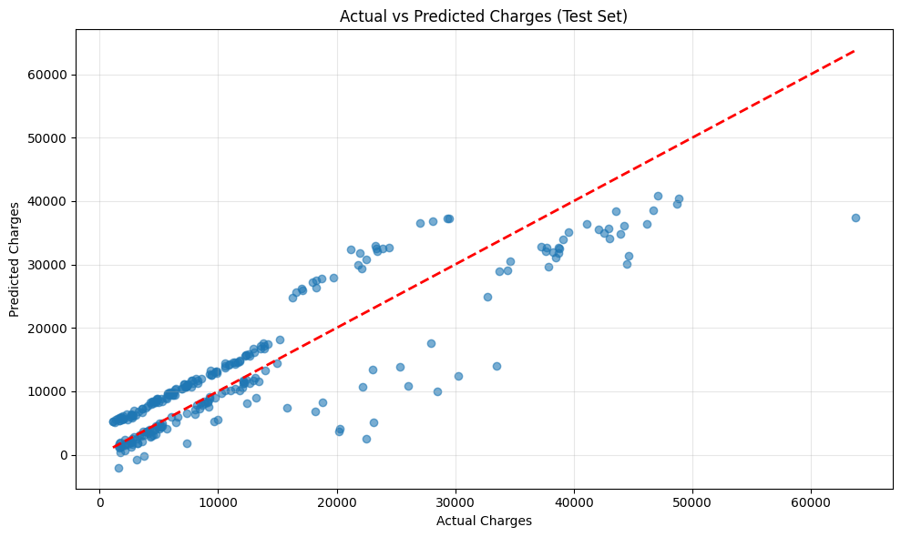

```python
# Plot actual vs. predicted values for test set

plt.figure(figsize=(10, 6))
plt.scatter(y_test, y_test_pred, alpha=0.6)
plt.plot([y_test.min(), y_test.max()], [y_test.min(), y_test.max()], 'r--', lw=2)
plt.xlabel('Actual Charges')
plt.ylabel('Predicted Charges')
plt.title('Actual vs Predicted Charges (Test Set)')
plt.grid(True, alpha=0.3)
plt.tight_layout()
plt.show()
```

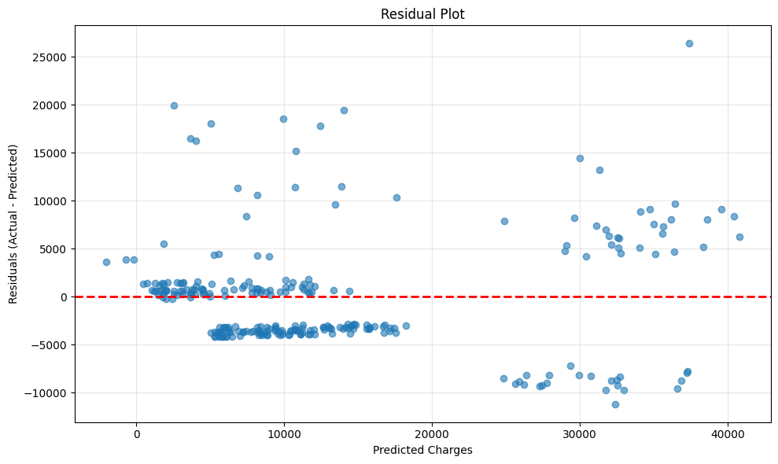

```python
# Plot residuals
residuals = y_test - y_test_pred

plt.figure(figsize=(10, 6))
plt.scatter(y_test_pred, residuals, alpha=0.6)
plt.axhline(y=0, color='r', linestyle='--', lw=2)
plt.xlabel('Predicted Charges')
plt.ylabel('Residuals (Actual - Predicted)')
plt.title('Residual Plot')
plt.grid(True, alpha=0.3)
plt.tight_layout()
plt.show()
```

## Ethical Concerns & Model Limitations

**Ethical Concerns**

- Could lead to discriminatory practices if the model is implemented (larger cost differences for "smokers" & "obese")
- Model uses senstive information (smoking, BMI, etc.) which needs to be handled carefully for individuals' privacy.
- Bias in the model can lead to unfair treatment (price differences based on region, sex, etc.)

**Data & Model Limitations**

- Feature set is fairly limited; could be other relevant factors like chronic conditions, lifestyle, medication usage, etc.
- Dataset could not be representative of all racial/ethnic groups; can perfrom poorly for under-represented populations
- RMSE and R-squared show good model performance overall, but the model could underperform for subgroups (age, region, etc.)

```python
!pip install nbconvert
```

```python
%% capture
! jupyter nbconvert --to html "/content/drive/MyDrive/Colab Notebooks/project1.ipynb" --output project
```